# Week 8: Network Data II - spatial and dynamic networks

## What if everyone was not sealed in together?

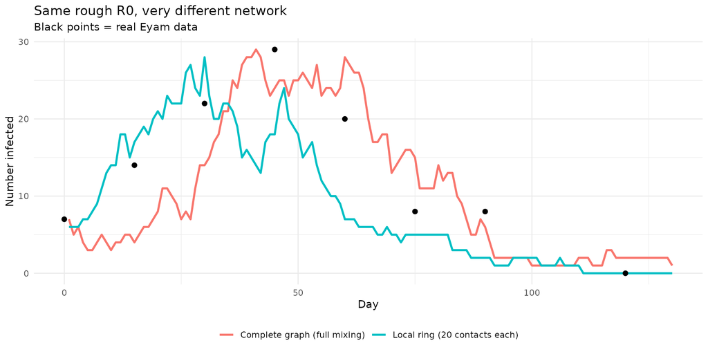

## What if everyone was not sealed in together?

Same disease, same recovery time, matched reproduction number on paper - and the local-contacts version peaks earlier, lower, and dies out faster than either the real village or the full-mixing model. Locally, small pockets flare up and burn through their own neighbours before the disease can find its way anywhere else; there’s no single synchronised wave the way there is when everyone can reach everyone. For Eyam specifically, the real curve favours the full-mixing story - which lines up with the historical account: a village sealed off together, with nowhere local to hide from one another.

That’s one run of each network, though - exactly the kind of claim Week 5 and 6 taught us to be suspicious of until we’ve checked it against more than one draw.

## Is that conclusion robust? 20 runs each

```r
runs_full  <- lapply(1:20, function(i) {
  cbind(simulate_sir(g_full, beta, gamma, n_init = 7, n_steps = 130, seed = i), run = i)
})
runs_local <- lapply(1:20, function(i) {
  cbind(simulate_sir(g_local, beta_local, gamma, n_init = 7, n_steps = 130, seed = i), run = i)
})

env_full  <- bind_rows(runs_full)  |> group_by(day) |>
  summarise(med = median(I), lo = quantile(I, .1), hi = quantile(I, .9)) |>
  mutate(model = "Complete graph")
env_local <- bind_rows(runs_local) |> group_by(day) |>
  summarise(med = median(I), lo = quantile(I, .1), hi = quantile(I, .9)) |>
  mutate(model = "Local ring")

ggplot(bind_rows(env_full, env_local), aes(day, med, colour = model, fill = model)) +
  geom_ribbon(aes(ymin = lo, ymax = hi), alpha = 0.25, colour = NA) +
  geom_line(linewidth = 1) +
  geom_point(data = eyam, aes(day, I), inherit.aes = FALSE, colour = "black", size = 2) +
  labs(title = "20 runs each, envelopes overlaid",
       subtitle = "Ribbon = 10th-90th percentile by calendar day; points = real Eyam data",
       x = "Day", y = "Number infected", colour = NULL, fill = NULL) +
  theme_minimal() + theme(legend.position = "bottom")
```

## Is that conclusion robust? 20 runs each

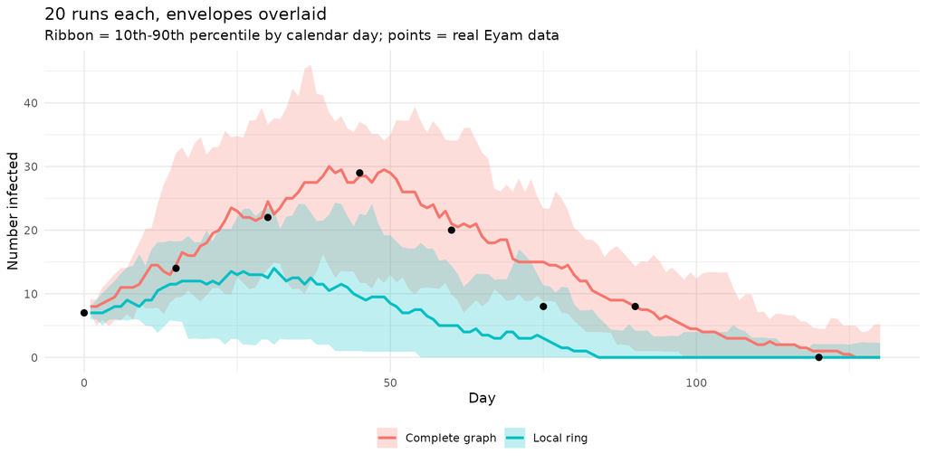

## Is that conclusion robust? 20 runs each

- The bands overlap at the start of the epidemics
- Some individual runs can be similar all the way
- Looking at **medians**: the complete graph’s sits above the local ring’s one, and peaks later
- Calendar-day ribbons can blur runs that peak at different times. Worth checking it properly

## A fairer comparison: per-run summaries

- If two runs both have a sharp peak of height 40, just five days apart, a day-by-day ribbon averages them into something that looks like one broad, flat-topped hump of height 40, not two sharp peaks
- Comparing whole trajectories, aligned to the calendar, can hide exactly a pattern we are trying to check
- Comparing one number *per run* instead sidesteps that problem entirely

## A fairer comparison: per-run summaries

```r
summary_df <- bind_rows(
  lapply(runs_full, function(d) data.frame(
    model = "Complete graph", peak_height = max(d$I),
    peak_day = which.max(d$I), final_size = tail(d$R, 1))),
  lapply(runs_local, function(d) data.frame(
    model = "Local ring", peak_height = max(d$I),
    peak_day = which.max(d$I), final_size = tail(d$R, 1)))
)

p1 <- ggplot(summary_df, aes(model, peak_height, colour = model)) +
  geom_jitter(width = 0.1, alpha = 0.6, size = 2) +
  stat_summary(fun = median, geom = "crossbar", width = 0.4, colour = "black") +
  labs(title = "Peak height", x = NULL, y = "Peak number infected") +
  theme_minimal() + theme(legend.position = "none")

p2 <- ggplot(summary_df, aes(model, peak_day, colour = model)) +
  geom_jitter(width = 0.1, alpha = 0.6, size = 2) +
  stat_summary(fun = median, geom = "crossbar", width = 0.4, colour = "black") +
  labs(title = "Day of peak", x = NULL, y = "Day") +
  theme_minimal() + theme(legend.position = "none")

p3 <- ggplot(summary_df, aes(model, final_size, colour = model)) +
  geom_jitter(width = 0.1, alpha = 0.6, size = 2) +
  stat_summary(fun = median, geom = "crossbar", width = 0.4, colour = "black") +
  labs(title = "Final attack size", x = NULL, y = "Total ever infected") +
  theme_minimal() + theme(legend.position = "none")

p1 + p2 + p3
```

## A fairer comparison: per-run summaries

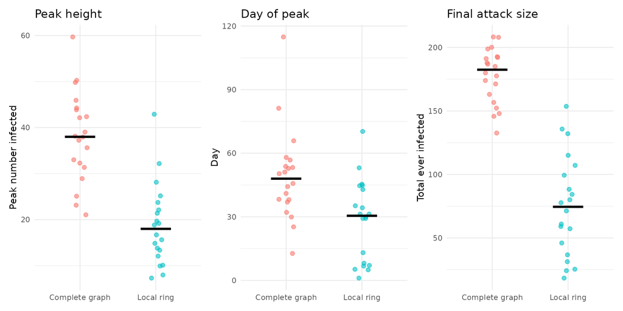

## Seeing the difference, not just counting it

```r
simulate_sir_with_history <- function(g, beta, gamma, n_init = 1, n_steps = 60, seed = NULL) {
  if (!is.null(seed)) set.seed(seed)
  n <- igraph::vcount(g)
  status <- rep("S", n)
  status[sample(n, n_init)] <- "I"
  history <- vector("list", n_steps)
  for (t in 1:n_steps) {
    infected <- which(status == "I")
    history[[t]] <- status
    if (length(infected) == 0) next
    new_infections <- integer(0)
    for (node in infected) {
      neighbours <- igraph::neighbors(g, node)
      sus <- neighbours[status[neighbours] == "S"]
      if (length(sus) > 0) {
        caught_it <- sus[runif(length(sus)) < beta]
        new_infections <- union(new_infections, as.integer(caught_it))
      }
    }
    recoveries <- infected[runif(length(infected)) < gamma]
    status[new_infections] <- "I"
    status[recoveries] <- "R"
  }
  history
}

set.seed(7)
g_small <- play_smallworld(n_dim = 1, dim_size = 60, order = 3, p = 0)
history <- simulate_sir_with_history(g_small, beta = 0.05, gamma = 0.08,
                                      n_init = 1, n_steps = 40, seed = 7)
lay <- create_layout(g_small, layout = "circle")

snapshot <- function(day) {
  g_t <- g_small |> activate(nodes) |> mutate(status = history[[day]])
  ggraph(g_t, layout = "manual", x = lay$x, y = lay$y) +
    geom_edge_link(alpha = 0.15) +
    geom_node_point(aes(colour = status), size = 2.5) +
    scale_colour_manual(values = c(S = "grey70", I = "firebrick", R = "steelblue")) +
    theme_void() + labs(title = paste("Day", day))
}
wrap_plots(lapply(c(4, 10, 18, 28), snapshot), nrow = 1) +
  plot_layout(guides = "collect")
```

## Seeing the difference, not just counting it

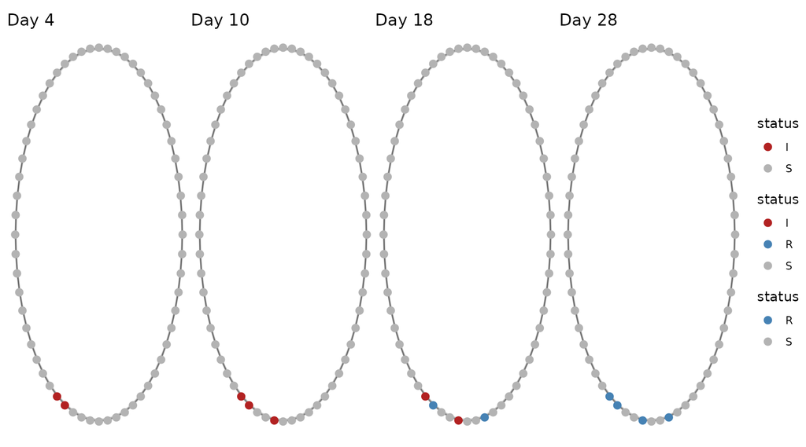

## Seeing the difference, not just counting it

- A small, purely local ring network (60 people, 6 contacts each) makes the mechanism visible
  - infection creeps around the ring as a wave front, rather than appearing everywhere at once the way it would on a complete graph.
- Same fixed layout throughout (Week 7’s rule) - any apparent movement is the epidemic, not the layout algorithm

## Last interpretation: thinking again about `beta`

- In the complete graph model, `beta` was 0.06%
- In the 20-neighbour ring model, `beta` became 0.78%
- Does a 0.06% daily transmission risk between two specific villagers sound right for close, sustained contact with someone infected with plague?
  - Or does 0.78% sound more like it?
  - So which graph is better??

## Dynamic networks: three representations

| Approach | Description | Tradeoff |
| --- | --- | --- |
| Snapshots (small multiples) | One panel per time point, as above | Does not scale past ~9-12 time points |
| Animation | Sequential frames | Engaging, but not reproducible as a static figure |
| Single static summary | e.g. final attack size, or “day infected” as node colour | Loses the time dimension entirely |

## The general recipe

What we actually did today, stripped of the specific example:

1. Start from a **real outbreak curve**. It tells you `n`, and roughly what shape and timescale you’re aiming for
2. Pick a **network assumption** that’s defensible for that specific situation (here: a sealed village $\to$ full mixing)
3. Set `gamma` from biology, tune `beta` until the shape is in the right ballpark. Run it more than once before you trust it
4. Try a **structurally different assumption** and see whether the fit gets better or worse. The comparison, not any single run, is the evidence
5. Explain the mismatch (or the good fit) in terms of *how the population is actually connected*, not just in terms of numbers

Portfolio 7 asks you to run exactly this recipe on a different real outbreak and a different trio of network models (ER, Barabási-Albert, Watts-Strogatz, all matched on mean degree). Today was about the process, not a preview of that specific comparison.

## References

- Raggett, G. F. (1982), *A stochastic model of the Eyam plague*, Journal of Applied Statistics - the original source for today’s data
- Bjørnstad (2018), *Epidemics: Models and Data using R*: chapters on simulating S/I/R-type models, stochastic simulation, and compartment-trajectory visualisation - this week’s core text
- Geographic Data Science with R: chapters on spatial networks / flow data (Lecture 1 background)
- Moraga (2020), *Geospatial Health Data*: spatial visualisation for real surveillance data, if your capstone uses it

## Course wrap-up preview

- Week 5: simulation $\to$ ensembles $\to$ ribbons
- Week 6: estimation uncertainty $\to$ CIs/PIs $\to$ distributional displays
- Week 7: network structure $\to$ encodings $\to$ representation choice
- Week 8: structure meets process - the same S/I/R logic behaves differently depending on *how* a population is connected

The Tutorial 3 capstone extends this further with real coordinates and time.

161.307 - Reproducible Visualisation for Statistics